# Introduction

## Display the Attributes of the Optimum Model

We now need to verify the success of the previous step's KNN workflow (pipeline) by displaying the details of the optimum model (i.e. its tuning parameter and score values) that it eventually selected.

```python
def print_summary2(opt_pipe_object):
    params = opt_pipe_object.best_estimator_.get_params()
    score = - opt_pipe_object.best_score_
    print("Nearest neighbours: %8d" % params['NNreg__n_neighbors'])
    print("Minkowski p       : %8d" % params['NNreg__p'])
    print("Weighting         : %8s" % params['NNreg__weights'])
    print("MAE Score         : %8.2f" % score)
    return

print_summary2(opt_nn2)
```

```
Nearest neighbours:       13
Minkowski p       :        1
Weighting         : distance
MAE Score         :    26.47
```

The above results show that the iterative cross-validation automation driven by the GridSearchCV function selected a KNN model with a k value (number of nearest neighbors) value of 13, a p value of 1 (for City Block distance) and a weighting type of distance (rather than uniform), and that those tuning parameter values yielded the (lowest) MAE scoring value of 26.47.

## Produce the Required 3D Plots

We now want to visualise what prices the optimum model predicts across London for houses of average floor area, and for floor areas of 75 and 125 square meters, respectively. To do this, we create a 100x100 grid (mesh) of points which span the area covered by the dataset's easting and northing ranges. Writing a function to produce the required type of 3D plot enables us to invoke it successively for the floor area values in which we are interested.

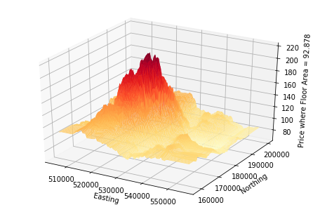

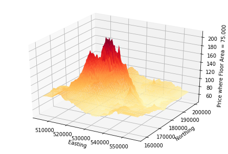

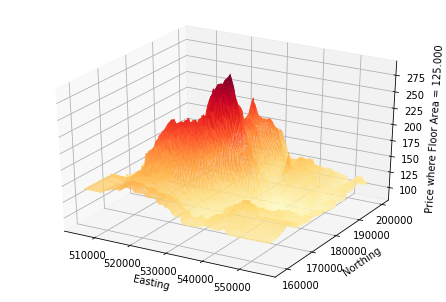

```python
def surf3d(pipe_model,fl_area):                           # Accept the model and floor area as input parameters
    zlabel = 'Price where Floor Area = %6.3f' % fl_area   # Set the label text for the z-axis based on floor area
    east_mesh, north_mesh = np.meshgrid(                  # Create the 100 x 100 grid (mesh) on the x-y plane using
        np.linspace(505000,555800,100),                   #   - easting value range and
        np.linspace(158400,199900,100))                   #   - northingvalue range
    fl_mesh = np.zeros_like(east_mesh)                    # Initialise the z-axis grid intervals to zeros (based on easting axis)
    fl_mesh[:,:] = fl_area                                # Set its values to that of the relevant input parameter
    grid_predictor_vars = np.array([east_mesh.ravel(),    # Merge (ravel) the x-, y- and z-axis into a single vector to suit the
        north_mesh.ravel(),fl_mesh.ravel()]).T            #    predict method of the specified model
    hp_pred = pipe_model.predict(grid_predictor_vars)     # Get the predicted house prices (as a vector)
    hp_mesh = hp_pred.reshape(east_mesh.shape)            # Split (unravel) the prediction vector into its x- y- and z-axis grid
                                                          #    components
    pl.close()                                            # Clear any previous plot (to ensure no overplotting)
    fig = pl.figure()                                     # Instantiate a plot object
    ax = Axes3D(fig)                                      # Draw the plot's 3 axes
    ax.plot_surface(east_mesh, north_mesh, hp_mesh,       # Draw the 3-D surface using the 3 grid (mesh) vectors
        rstride=1, cstride=1, cmap='YlOrRd',lw=0.01)      #    and a Yellow-Orange-Red colour ramp
    ax.set_xlabel('Easting')                              # Label the c-, y- and z-axes
    ax.set_ylabel('Northing')
    ax.set_zlabel(zlabel)
    pl.show()                                             # Display the plot
    return

surf3d(opt_nn2,np.mean(hp["fl_area"]))                    # Produce the 3D surface plot for the average floor area
surf3d(opt_nn2,75)                                        #    and for a floor area of 75 square meters
surf3d(opt_nn2,125)                                       #    and for a floor area of 125 square meters
```